# Explanations of Model Predictions with live and breakDown Packages

## Shapley values (SHAP)

Authors of the original article about Shapley values maintain a Python package which implements several methods of computing these values. Also, it provides visual diagnostic tools that help understand global behavior of the black box model such as plotting variable contributions for all instances in the dataset.

The *iml* package can be used to compute Shapley values for any model. Other tools are more restricted in this regard, for example, the *shapleyR* package only works with *mlr* models. First, we need to create a `Predictor` object for the model, then it is enough to apply the `Shapley` function for a specified instance. This implementation samples permutation of variables to take into account different orders in which conditioning can be done and the number of permutations to be used is a parameter of this function. Details can be found in the documentation for the package.

```r
model_svm = Predictor$new(model = wine_svm, data = wine[, -nc], y = wine$quality)
set.seed(17)
shapley_iml = Shapley$new(model_svm, x.interest = wine[5, -nc])
plot(shapley_iml)
```

Calculated Shapley values[^7] are presented in Table 2 and compared to results of Break Down method. Shapley values can be also visualized on a plot similar to waterfall plot, which can be created using generic `plot` function. An example is shown in Figure 8.

Table 2: Comparison of feature attributions calculated with *iml* and *breakDown* packages.

|  | feature | Shapley value | breakDown score |
| --- | --- | --- | --- |
| 1 | alcohol | -0.31 | -0.32 |
| 2 | volatile_acidity | -0.23 | -0.19 |
| 3 | sulphates | -0.19 | -0.07 |
| 4 | citric_acid | 0.17 | 0.14 |
| 5 | fixed_acidity | -0.06 | 0.02 |
| 6 | pH | -0.04 | -0.08 |
| 7 | density | -0.03 | -0.03 |
| 8 | residual_sugar | -0.01 | -0.03 |
| 9 | total_sulfur_dioxide | 0.00 | -0.00 |
| 10 | chlorides | -0.00 | -0.02 |
| 11 | free_sulfur_dioxide | 0.00 | 0.00 |

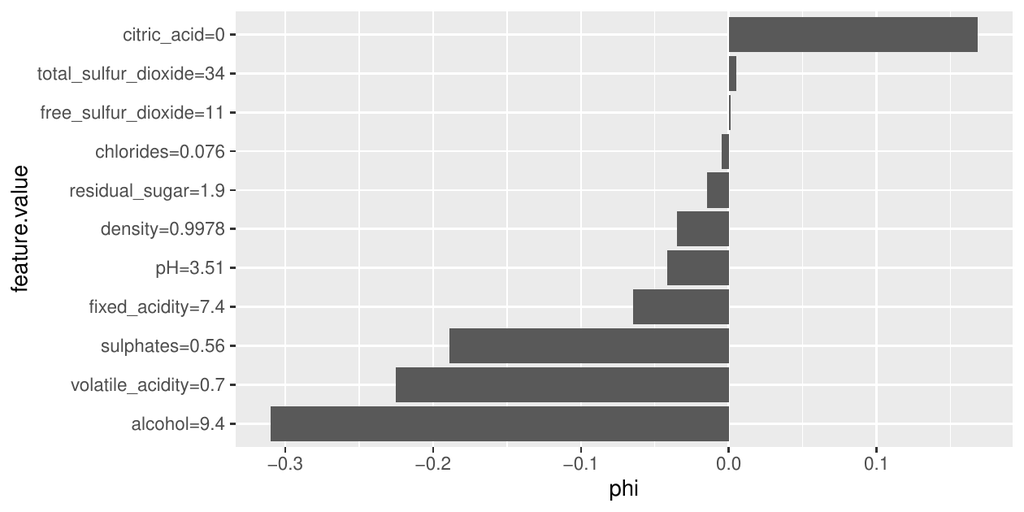

Figure 8: Visualization of Shapley values.

# Discussion

In this paper, we presented four approaches and four R packages that can be used for explanations of predictions from complex black box models. Two of them have already been introduced in literature, while *live* and *breakDown* were introduced in this article for the first time.

All four approaches are model agnostic in a sense that, the method does not depend on any particular structure of black box model. Yet there are also some differences between these approaches.

# Acknowledgements

Work on this article is financially supported by the *NCN Opus grant 2017/27/B/ST6/01307*.

Altmann, André, Laura Toloşi, Oliver Sander, and Thomas Lengauer. 2010. “Permutation Importance: A Corrected Feature Importance Measure.” *Bioinformatics* 26 (10): 1340–47.

Apley, D. W. 2016. “Visualizing the Effects of Predictor Variables in Black Box Supervised Learning Models.” *ArXiv e-Prints*. https://arxiv.org/abs/1612.08468.

Biecek, Przemyslaw. 2018. “DALEX: Explainers for Complex Predictive Models.” *ArXiv e-Prints*. https://arxiv.org/abs/1806.08915.

Biecek, Przemyslaw, and Marcin Kosinski. 2017. “archivist: An R Package for Managing, Recording and Restoring Data Analysis Results.” *Journal of Statistical Software* 82 (11): 1–28. https://doi.org/10.18637/jss.v082.i11.

Bischl, Bernd, Michel Lang, Lars Kotthoff, Julia Schiffner, Jakob Richter, Erich Studerus, Giuseppe Casalicchio, and Zachary M. Jones. 2016. “mlr: Machine Learning in r.” *Journal of Machine Learning Research* 17 (170): 1–5.

Chen, Tianqi, Tong He, Michael Benesty, Vadim Khotilovich, Yuan Tang, Hyunsu Cho, Kailong Chen, et al. 2018. *Xgboost: Extreme Gradient Boosting*. https://CRAN.R-project.org/package=xgboost.

Cortez, Paulo, António Cerdeira, Fernando Almeida, Telmo Matos, and José Reis. 2009. “Modeling Wine Preferences by Data Mining from Physicochemical Properties.” *Decis. Support Syst.* 47 (4): 547–53. https://doi.org/10.1016/j.dss.2009.05.016.

Dowle, Matt, and Arun Srinivasan. 2017. *Data.table: Extension of ‘Data.frame‘*. https://CRAN.R-project.org/package=data.table.

Fogg, Andrew. 2016. *Anthony Goldbloom Gives You the Secret to Winning Kaggle Competitions*.

Friedman, Jerome H. 2001. “Greedy Function Approximation: A Gradient Boosting Machine.” *Ann. Statist.* 29 (5): 1189–1232. https://doi.org/10.1214/aos/1013203451.

Friedman, Jerome, Trevor Hastie, and Robert Tibshirani. 2010. “Regularization Paths for Generalized Linear Models via Coordinate Descent.” *Journal of Statistical Software* 33 (1): 1–22. https://doi.org/10.18637/jss.v033.i01.

Goldstein, Alex, Adam Kapelner, Justin Bleich, and Emil Pitkin. 2015. “Peeking Inside the Black Box: Visualizing Statistical Learning With Plots of Individual Conditional Expectation.” *Journal of Computational and Graphical Statistics* 24 (1): 44–65. https://doi.org/10.1080/10618600.2014.907095.

Greenwell, Brandon M. 2017. “Pdp: An r Package for Constructing Partial Dependence Plots.” *The R Journal* 9 (1): 421–36. https://doi.org/10.32614/rj-2017-016.

Kennedy, Nick. 2017. *Forestmodel: Forest Plots from Regression Models*. https://CRAN.R-project.org/package=forestmodel.

Kuhn, Max. 2018. *Caret: Classification and Regression Training*. https://CRAN.R-project.org/package=caret.

Liaw, Andy, and Matthew Wiener. 2002. “Classification and Regression by randomForest.” *R News* 2 (3): 18–22.

Lundberg, Scott M, and Su-In Lee. 2017. “A Unified Approach to Interpreting Model Predictions.” In *Advances in Neural Information Processing Systems 30*, edited by I. Guyon, U. V. Luxburg, S. Bengio, H. Wallach, R. Fergus, S. Vishwanathan, and R. Garnett, 4765–74. Curran Associates, Inc.

Meyer, David, Evgenia Dimitriadou, Kurt Hornik, Andreas Weingessel, and Friedrich Leisch. 2018. *E1071: Misc Functions of the Department of Statistics, Probability Theory Group (Formerly: E1071), TU Wien*. https://CRAN.R-project.org/package=e1071.

Molnar, Christoph, Bernd Bischl, and Giuseppe Casalicchio. 2018. “Iml: An r Package for Interpretable Machine Learning.” *JOSS* 3 (26): 786. https://doi.org/10.21105/joss.00786.

Pedersen, Thomas Lin, and Michaël Benesty. 2018. *Lime: Local Interpretable Model-Agnostic Explanations*. https://CRAN.R-project.org/package=lime.

Puri, N., P. Gupta, P. Agarwal, S. Verma, and B. Krishnamurthy. 2017. “MAGIX: Model Agnostic Globally Interpretable Explanations.” *ArXiv e-Prints*. https://arxiv.org/abs/1706.07160.

Ribeiro, Marco Tulio, Sameer Singh, and Carlos Guestrin. 2016. “"Why Should i Trust You?": Explaining the Predictions of Any Classifier.” In *Proceedings of the 22Nd ACM SIGKDD International Conference on Knowledge Discovery and Data Mining*, 1135–44. KDD ’16. New York, NY, USA: ACM. https://doi.org/10.1145/2939672.2939778.

Robnik-Šikonja, M., and I. Kononenko. 2008. “Explaining Classifications for Individual Instances.” *IEEE Transactions on Knowledge and Data Engineering* 20 (5): 589–600. https://doi.org/10.1109/tkde.2007.190734.

Simon, Noah, Jerome Friedman, Trevor Hastie, and Rob Tibshirani. 2011. “Regularization Paths for Cox’s Proportional Hazards Model via Coordinate Descent.” *Journal of Statistical Software* 39 (5): 1–13. https://doi.org/10.18637/jss.v039.i05.

Strobl, Carolin, Anne-Laure Boulesteix, Thomas Kneib, Thomas Augustin, and Achim Zeileis. 2008. “Conditional Variable Importance for Random Forests.” *BMC Bioinformatics* 9 (307).

Štrumbelj, Erik, and Igor Kononenko. 2011. “A General Method for Visualizing and Explaining Black-Box Regression Models.” In *Proceedings of the 10th International Conference on Adaptive and Natural Computing Algorithms - Volume Part II*, 21–30. ICANNGA’11. Berlin, Heidelberg: Springer-Verlag. https://doi.org/10.1007/978-3-642-20267-4_3.

Tulio Ribeiro, M., S. Singh, and C. Guestrin. 2016. “Nothing Else Matters: Model-Agnostic Explanations By Identifying Prediction Invariance.” *ArXiv e-Prints*. https://arxiv.org/abs/1611.05817.

Tzeng, F. Y., and K. L. Ma. 2005. “Opening the Black Box - Data Driven Visualization of Neural Networks.” In *VIS 05. IEEE Visualization, 2005.*, 383–90. https://doi.org/10.1109/visual.2005.1532820.

Zeiler, Matthew D., and Rob Fergus. 2014. “Visualizing and Understanding Convolutional Networks.” In *Computer Vision – ECCV 2014*, 818–33. Springer-Verlag. https://doi.org/10.1007/978-3-319-10590-1_53.

[^1]: https://github.com/MI2DataLab/pyBreakDown/
[^2]: Access this model with `archivist::aread("MI2DataLab/live/arepo/1025d")`
[^3]: Access this model with `archivist::aread("MI2DataLab/live/arepo/eebe6")`
[^4]: Access this object with `archivist::aread("MI2DataLab/live/arepo/878d5")`
[^5]: Access example attributions with `archivist::aread("MI2DataLab/live/arepo/1f320")`
[^6]: https://pbiecek.github.io/breakDown/
[^7]: Access this object with `archivist::aread("MI2DataLab/live/arepo/50f5f")`